# Making your code faster: Introduction to vectorisation and parallel computing

Tom Kelly

5/25/2019

## Analysis of Gapminder Data

We will use the [Gapminder dataset](https://www.gapminder.org/data/) for demonstrations. This has data about 142 countries/regions around the world, every 5 years from 1952 to 2007. We will download this data from the Software Carpentry lesson materials on GitHub.

```r
# input data

system("wget raw.githubusercontent.com/swcarpentry/r-novice-gapminder/master/data/gapminder_data.csv")
gapminder_data <- data.table::fread("gapminder_data.csv", data.table = FALSE)
dim(gapminder_data)
```

```
## [1] 1704    6
```

```r
head(gapminder_data)
```

```
##       country year      pop continent lifeExp gdpPercap
## 1 Afghanistan 1952  8425333      Asia  28.801  779.4453
## 2 Afghanistan 1957  9240934      Asia  30.332  820.8530
## 3 Afghanistan 1962 10267083      Asia  31.997  853.1007
## 4 Afghanistan 1967 11537966      Asia  34.020  836.1971
## 5 Afghanistan 1972 13079460      Asia  36.088  739.9811
## 6 Afghanistan 1977 14880372      Asia  38.438  786.1134
```

## Basic Computational tasks

Let’s start with a basic task (that we want to do many times). For example, let’s compute the average life expectancy for Asia in 2002.

```r
mean(gapminder_data[gapminder_data$continent == "Asia" & gapminder_data$year == "2002",]$lifeExp)
```

```
## [1] 69.23388
```

Now suppose that we want to do this again. Let’s do it again for each continent: why not copy-paste? **Do not do this**. You will introduce human errors into your code, it is tedious to write and difficult to fix and run again. If you find a problem, you need to correct every instance where that problem occurs.

```r
mean(gapminder_data[gapminder_data$continent == "Asia" & gapminder_data$year == "2002",]$lifeExp)
```

```
## [1] 69.23388
```

```r
mean(gapminder_data[gapminder_data$continent == "Africa" & gapminder_data$year == "2002",]$lifeExp)
```

```
## [1] 53.32523
```

```r
mean(gapminder_data[gapminder_data$continent == "Europe" & gapminder_data$year == "2002",]$lifeExp)
```

```
## [1] 76.7006
```

```r
mean(gapminder_data[gapminder_data$continent == "Australasia" & gapminder_data$year == "2002",]$lifeExp)
```

```
## [1] NaN
```

```r
mean(gapminder_data[gapminder_data$continent == "Americas" & gapminder_data$year == "2002",]$lifeExp)
```

```
## [1] 72.42204
```

Note that it is easy to make mistakes here. These inputs do not match the Continents in the dataset.

```r
table(gapminder_data$continent)
```

```
##
##   Africa Americas     Asia   Europe  Oceania
##      624      300      396      360       24
```

## Doing Repetitive Tasks

You can compute repetitive tasks to make sure they are treated the same. This has several benefits:

- takes less time to write the code
- reduces human errors when one line has a mistake
- easy to change and run same process on many inputs again (if all lines have a mistake)
- sometimes runs faster (vectorised or parallel)
- you specify all input conditions at the beginning (lees likely you will miss one)

There are serveral ways to do this:

- vectorised functions (for simple scalar operations)
- create your own function (to run with many **different** inputs and to **share** tools as packages)
- apply a function (to list or matrix data)
- run processes iteratively in a LOOP (sequential)
- run multiple threads or processes in **parallel** on different COREs or threads (cpu or gpu).

### Vectorised commands

Some commands in R have built-in vectorised operations. They can take input as either a scalar (one element) or a vector (many elements). This is the simplest way to perform multiple operations at the same time. They run sequentially but results are returned simultaneously as a vector. This is ideal for basic operations.

For example, we can square each number as scalar:

```r
#scalar operation
1^2
```

```
## [1] 1
```

```r
2^2
```

```
## [1] 4
```

```r
3^2
```

```
## [1] 9
```

This operation is takes a vector input and returns a vector of the same length. The same operation is performed on each element separately. These operations only apply to each element alone and *cannot* take outputs from other elements as the input (in a single operation).

vectorisation: *perform an operation for EACH element in a VECTOR*

```r
#vector operation
c(1:3)^2
```

```
## [1] 1 4 9
```

```r
c(1:10)^2
```

```
##  [1]   1   4   9  16  25  36  49  64  81 100
```

### FOR Loop

For more complex operations we can use a for loop to run the same operation on each element in the inputs. Each input is substituted into the loop sequentially. These operations occur in *order* and can depend on the output of previous operations.

For example,if we doing something (generally more complex) with exactly the same for many arguments: we use a FOR Loop.

Loop: *FOR EACH element IN inputs DO operation*

```r
print(paste0(1, "^2 = ", 1^2))
```

```
## [1] "1^2 = 1"
```

```r
for(ii in 1:4){
  print(paste0(ii, "^2 = ", ii^2))
}
```

```
## [1] "1^2 = 1"
## [1] "2^2 = 4"
## [1] "3^2 = 9"
## [1] "4^2 = 16"
```

So we can compute the mean Life Expectancy for each possible continent as follows:

```r
for(continent in unique(gapminder_data$continent)){
  print(
  mean(gapminder_data[gapminder_data$continent == continent & gapminder_data$year == "2002",]$lifeExp)
  )
}
```

```
## [1] 69.23388
## [1] 76.7006
## [1] 53.32523
## [1] 72.42204
## [1] 79.74
```

It is [recommended](https://www.r-bloggers.com/growing-objects-and-loop-memory-pre-allocation/) to initialise an object of the right size (to “pre-allocate” memory) to add the sequential outputs to this output. Replacing the object with a larger object (appending) is not efficient for memory in R, especially for large operations or data. *Do not use c() or cbind() in a for loop*.

```r
mean_by_cont <- rep(NA, length(unique(gapminder_data$continent)))
for(continent in unique(gapminder_data$continent)){
  ii <- match(continent, unique(gapminder_data$continent))
  mean_by_cont[ii] <- mean(gapminder_data[gapminder_data$continent == continent & gapminder_data$year == "2002",]$lifeExp)
}
names(mean_by_cont) <- unique(gapminder_data$continent)
mean_by_cont
```

```
##     Asia   Europe   Africa Americas  Oceania
## 69.23388 76.70060 53.32523 72.42204 79.74000
```

For loops are very flexible and can do almost any operation (although complex loops can take a *long* time to run). They can be re-written (optimised or refactored) to run more efficiently. So they are a good *starting point* to develop code and get fast results (without spending more time of your own). You can put a for loop inside another for loop to do more complex operatons. For example, this is a *nested for loop* to take two different arguments and compute mean for each *continent* for each *year*. This generates a separate mean for each element of a (2-dimensional) matrix.

```r
# doing something for different arguments: nested FOR Loop (can get messy)
mean_by_cont <- matrix(NA, length(unique(gapminder_data$year)), length(unique(gapminder_data$continent)))
for(continent in unique(gapminder_data$continent)){ # for every continent (as columns)
  jj <- match(continent, unique(gapminder_data$continent))
  for(year in unique(gapminder_data$year)){ # for every year (as rows)
    ii <- match(year, unique(gapminder_data$year))
    mean_by_cont[ii, jj] <- mean(gapminder_data[gapminder_data$continent == continent & gapminder_data$year == year,]$lifeExp)
  }
}
colnames(mean_by_cont) <- unique(gapminder_data$continent)
rownames(mean_by_cont) <- unique(gapminder_data$year)
mean_by_cont
```

```
##          Asia   Europe   Africa Americas Oceania
## 1952 46.31439 64.40850 39.13550 53.27984 69.2550
## 1957 49.31854 66.70307 41.26635 55.96028 70.2950
## 1962 51.56322 68.53923 43.31944 58.39876 71.0850
## 1967 54.66364 69.73760 45.33454 60.41092 71.3100
## 1972 57.31927 70.77503 47.45094 62.39492 71.9100
## 1977 59.61056 71.93777 49.58042 64.39156 72.8550
## 1982 62.61794 72.80640 51.59287 66.22884 74.2900
## 1987 64.85118 73.64217 53.34479 68.09072 75.3200
## 1992 66.53721 74.44010 53.62958 69.56836 76.9450
## 1997 68.02052 75.50517 53.59827 71.15048 78.1900
## 2002 69.23388 76.70060 53.32523 72.42204 79.7400
## 2007 70.72848 77.64860 54.80604 73.60812 80.7195
```

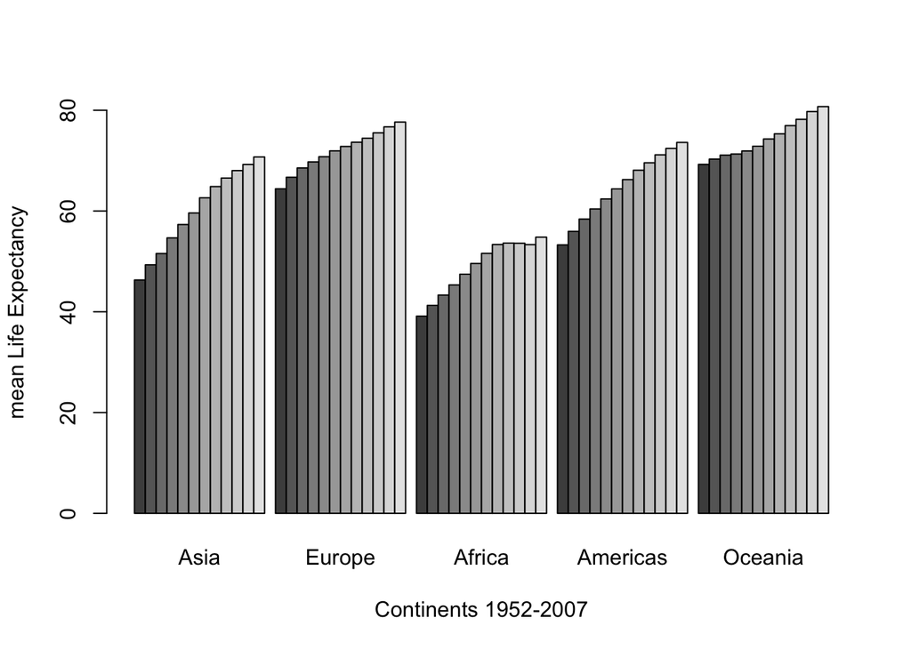

```r
barplot(mean_by_cont, beside=TRUE, ylab = "mean Life Expectancy", xlab = "Continents 1952-2007")
```

### Writing and Using Functions

You can *create* your own functions. Compared to a loop this has several advantages:

- you can reuse this function later in your own scripts
- you can perform only the inputs that you need (not all combinations in a loop)
- you can add more inputs
- you can share these in package to reuse to apply in other analyses (please *document* what they do and what inputs they need)
- it is easier to read code broken down into smaller functions for each task
- functions are efficient for memory (not cpu-time) as they call all steps at once and return only the outputs needed to the environment (see: variable scoping)
- functions make *debugging* easier as you only need to fix the function to run the correct analysis again

Some people recommend to *write a function every time you need to do something more than ONCE*. You should if you are going to use it more than 3-5 times. R supports both *functional programming* and *object-oriented programming*. You do not need a deep understanding of these concepts to use functions in your code.

Functions: *perform an operation on an INPUT and RETURN and OUTPUT*

We can create and call a function to perform the mean for a continent as follows.

```r
continent_mean <- function(continent){
  mean(gapminder_data[gapminder_data$continent == continent & gapminder_data$year == "2002",]$lifeExp)
}
continent_mean("Africa")
```

```
## [1] 53.32523
```

Note that this requires an input to run:

```r
continent_mean()
```

```
## Error in `[.data.frame`(gapminder_data, gapminder_data$continent == continent & : argument "continent" is missing, with no default
```

The *default* continent can be given as follows. Other inputs can be given. The function will *revert* to the default argument if no other input is specified (just like built-in R commands).

```r
continent_mean <- function(continent = "Europe"){
  mean(gapminder_data[gapminder_data$continent == continent & gapminder_data$year == "2002",]$lifeExp)
}
continent_mean("Africa")
```

```
## [1] 53.32523
```

```r
continent_mean() #Europe is default
```

```
## [1] 76.7006
```

Notice that the above function can run on ANY continent but will only compute values for the year 2002 in the gapminder dataset. This is because the function is *hardcoded*. This is *not recommended*. You will need to write a new function if you want to compute a different. To *avoid* this you can define another argument in a function to pass these into the function so it can compute any dataset (in this format):

```r
continent_mean <- function(data, continent = "Europe"){
  mean(data[data$continent == continent & data$year == "2002",]$lifeExp)
}
continent_mean(gapminder_data, "Africa") # compatible with other datasets (not "harcoded")
```

```
## [1] 53.32523
```

```r
continent_mean(gapminder_data) #Europe is default for "continent
```

```
## [1] 76.7006
```

A function can take as many inputs as required (but only one output object). We can add the year as follows:

```r
continent_mean <- function(data, continent = "Europe", year = 2002){
  mean(data[data$continent == continent & data$year == year,]$lifeExp)
}
continent_mean(gapminder_data) #Europe 2002 is default
```

```
## [1] 76.7006
```

```r
continent_mean(gapminder_data, year = "1972", continent = "Asia") #Europe 2002 is default
```

```
## [1] 57.31927
```

Now we can run our function on different inputs instead of copying the code:

```r
continent_mean(gapminder_data, year = "1972", continent = "Asia") #Europe 2002 is default
```

```
## [1] 57.31927
```

```r
continent_mean(gapminder_data, year = "1972", continent = "Africa") #Europe 2002 is default
```

```
## [1] 47.45094
```

```r
continent_mean(gapminder_data, year = "1972", continent = "Americas") #Europe 2002 is default
```

```
## [1] 62.39492
```

#### Functions and Loops can be combined

Let’s do our nested LOOP again with this function:

```r
continent_mean(gapminder_data, year = "1972", continent = "Asia")
```

```
## [1] 57.31927
```

```r
mean_by_cont <- matrix(NA, length(unique(gapminder_data$year)), length(unique(gapminder_data$continent)))
for(continent in unique(gapminder_data$continent)){
  jj <- match(continent, unique(gapminder_data$continent))
  for(year in unique(gapminder_data$year)){
    ii <- match(year, unique(gapminder_data$year))
    mean_by_cont[ii, jj] <- continent_mean(gapminder_data, continent, year)
  }
}
colnames(mean_by_cont) <- unique(gapminder_data$continent)
rownames(mean_by_cont) <- unique(gapminder_data$year)
mean_by_cont
```

```
##          Asia   Europe   Africa Americas Oceania
## 1952 46.31439 64.40850 39.13550 53.27984 69.2550
## 1957 49.31854 66.70307 41.26635 55.96028 70.2950
## 1962 51.56322 68.53923 43.31944 58.39876 71.0850
## 1967 54.66364 69.73760 45.33454 60.41092 71.3100
## 1972 57.31927 70.77503 47.45094 62.39492 71.9100
## 1977 59.61056 71.93777 49.58042 64.39156 72.8550
## 1982 62.61794 72.80640 51.59287 66.22884 74.2900
## 1987 64.85118 73.64217 53.34479 68.09072 75.3200
## 1992 66.53721 74.44010 53.62958 69.56836 76.9450
## 1997 68.02052 75.50517 53.59827 71.15048 78.1900
## 2002 69.23388 76.70060 53.32523 72.42204 79.7400
## 2007 70.72848 77.64860 54.80604 73.60812 80.7195
```

#### Applying functions to a list or matrix

We can also “apply” functions to a list or matrix. This is an effective way to perform an operation each element of a list or vector. Similar to *vectorised* commands, applying a function can perform more complex operations. This is recommended in R for running existing functions on each on a list.

Apply: *perform a FUNCTION on EACH element of a LIST* or *perform a FUNCTION on each row/column of a MATRIX*

```r
#apply to a list
numbers <- list(1:10, c(0,4,6,2,8))
numbers
```

```
## [[1]]
##  [1]  1  2  3  4  5  6  7  8  9 10
##
## [[2]]
## [1] 0 4 6 2 8
```

```r
max(numbers[[1]])
```

```
## [1] 10
```

```r
lapply(numbers, max)
```

```
## [[1]]
## [1] 10
##
## [[2]]
## [1] 8
```

```r
sapply(numbers, max)
```

```
## [1] 10  8
```

Similarly, an apply function can be used to run a function on a row (1) or column (2) of a matrix or data frame. For example, we can compute the GDP for each row (each country and year) with the following function. We can create functions within the apply call.

```r
#apply to a matrix/data.frame (e.g., for every country)
gdp <- apply(gapminder_data, 1, function(x) as.numeric(x[[6]]) * as.numeric(x[[3]]))
gapminder_data$gdp <- gdp
head(gapminder_data)
```

```
##       country year      pop continent lifeExp gdpPercap         gdp
## 1 Afghanistan 1952  8425333      Asia  28.801  779.4453  6567086208
## 2 Afghanistan 1957  9240934      Asia  30.332  820.8530  7585448397
## 3 Afghanistan 1962 10267083      Asia  31.997  853.1007  8758855694
## 4 Afghanistan 1967 11537966      Asia  34.020  836.1971  9648013709
## 5 Afghanistan 1972 13079460      Asia  36.088  739.9811  9678553198
## 6 Afghanistan 1977 14880372      Asia  38.438  786.1134 11697659826
```

We can also apply functions to columns, including subsets of the data (the function will be performed on *every* column given so make sure types are suitable). Arguments can be passed to the function after the function input or by defining a function as shown:

```r
#apply to a matrix columns
apply(gapminder_data[grep("2002", gapminder_data$year),c(3, 5, 6)], 2, sum, na.rm = TRUE)
```

```
##          pop      lifeExp    gdpPercap
## 5.886978e+09 9.328679e+03 1.408334e+06
```

```r
apply(gapminder_data[grep("2002", gapminder_data$year),c(3, 5, 6)], 2, function(x) sum(x, na.rm = TRUE))
```

```
##          pop      lifeExp    gdpPercap
## 5.886978e+09 9.328679e+03 1.408334e+06
```

Using this approach, we can compute a list or vector of means for each continent (equivalent to the FOR loop).

```r
lapply(unique(gapminder_data$continent), function(continent){
  continent_mean(gapminder_data, continent, year = "2002")
  })
```

```
## [[1]]
## [1] 69.23388
##
## [[2]]
## [1] 76.7006
##
## [[3]]
## [1] 53.32523
##
## [[4]]
## [1] 72.42204
##
## [[5]]
## [1] 79.74
```

```r
sapply(unique(gapminder_data$continent), function(continent){
  continent_mean(gapminder_data, continent, year = "2002")
})
```

```
##     Asia   Europe   Africa Americas  Oceania
## 69.23388 76.70060 53.32523 72.42204 79.74000
```

### Parallel computing

We can use the “snow” (Simple Network Of Workstations) package to run functions in *parallel*. This uses a similar process as the “apply” functions. Let’s start with a simple example of an apply function and run ir again in parallel.

In this case, we do not need to wait for each result to compute the next one. This is called *embarrassingly parallel* computing. This is the best situation for setting up a parallel computation:

- independent processes do need rely on the output of other processes (no communication between cores needed)
- the operations are complex and computationally intensive (time to set up cluster is justified)

```r
lapply(1:10, function(ii) ii^2)
```

```
## [[1]]
## [1] 1
##
## [[2]]
## [1] 4
##
## [[3]]
## [1] 9
##
## [[4]]
## [1] 16
##
## [[5]]
## [1] 25
##
## [[6]]
## [1] 36
##
## [[7]]
## [1] 49
##
## [[8]]
## [1] 64
##
## [[9]]
## [1] 81
##
## [[10]]
## [1] 100
```

Parallel Apply: *perform a FUNCTION on EACH input in PARALLEL*

```r
library("snow") # simple network of workstations
cl <- makeCluster(3)
cl
```

```
## socket cluster with 3 nodes on host 'localhost'
```

```r
parLapply(cl, 1:10, function(ii) ii^2)
```

```
## [[1]]
## [1] 1
##
## [[2]]
## [1] 4
##
## [[3]]
## [1] 9
##
## [[4]]
## [1] 16
##
## [[5]]
## [1] 25
##
## [[6]]
## [1] 36
##
## [[7]]
## [1] 49
##
## [[8]]
## [1] 64
##
## [[9]]
## [1] 81
##
## [[10]]
## [1] 100
```

What “makeCluster” does is set up the cluster (group of cores) to send the jobs to. The function will be run on each core separately (at the same time) and each output returned as an element. Above we are running this function on 3 cores. This sets up a *multithreaded* process to run 3 threads. 3 inputs will run at the same time. The rest will wait until one of the cores is available to do the next one.

Using “makeCluster” it will default to the suitable type for your system. It is recommended to use a Socket Cluster (“makeSOCKcluster) as this can run on any cluster including separate nodes or local machines. On some systems and MPI cluster (”makeMPIcluster“) is recommended to reduce load on communication but this is only compatible with some hardware systems and requires”OpenMP" C library and “Rmpi” to be installed (this *is not needed* for a local machine). Contact the administrators or support for servers and HPC systems for recommendations to optimise code on their system.

```r
system("rm outs.txt")
system("touch outs.txt")
```

```r
library("snow")
cl <- makeCluster(3)
cl
```

```
## socket cluster with 3 nodes on host 'localhost'
```

```r
parLapply(cl, 1:10, function(ii){
  print(ii)
  write.table(ii^2, "outs.txt", append = TRUE)
  return(ii^2)
  })
```

```
## [[1]]
## [1] 1
##
## [[2]]
## [1] 4
##
## [[3]]
## [1] 9
##
## [[4]]
## [1] 16
##
## [[5]]
## [1] 25
##
## [[6]]
## [1] 36
##
## [[7]]
## [1] 49
##
## [[8]]
## [1] 64
##
## [[9]]
## [1] 81
##
## [[10]]
## [1] 100
```

```r
system("cat outs.txt")
```

Note that more cores is not always faster. The theoretical *speed up* will be less if you add more cores as it takes more resources to set up the server (overhead time) and communication between cores. Embarrassingly parallel is ideal for this since communiation is *only* needed to send input and outputs to the main core. “stopCluster” should be called before exiting R or creating another cluster.

```r
# note more cores is not always faster (Amdahl's law) due to set up time and core-to-core communication

system.time({
  library("snow") # simple network of workstations
  cl <- makeCluster(1)
  cl
  out <- parLapply(cl, 1:1000, function(ii) ii^2)
})
```

```
##    user  system elapsed
##   0.003   0.003   0.229
```

```r
stopCluster(cl)
```

```r
system.time({
library("snow") # simple network of workstations
cl <- makeCluster(3)
cl
out <- parLapply(cl, 1:1000, function(ii) ii^2)
})
```

```
##    user  system elapsed
##   0.005   0.005   0.664
```

```r
stopCluster(cl)
```

```r
system.time({
  library("snow") # simple network of workstations
  cl <- makeCluster(10) # more than on machine
  cl
  out <- parLapply(cl, 1:1000, function(ii) ii^2)
})
```

```
##    user  system elapsed
##   0.016   0.020   1.964
```

```r
stopCluster(cl)
```

Here we compare the performance of computing the mean for each continent in an “apply” function and in “parallel”. The important point is to give the cluster to the parallel function on which to run. The cores must also have the objects exported to them. Each core has it’s own environment. You must use “clusterExport” to pass input data to the cores. You can use `clusterExport(cl, ls())` to pass all objects in the environment. Any changes to objects (by each core) in each function call on each input will not affect the others (variable scoping).

```r
system.time({
lapply(unique(gapminder_data$continent), function(continent){
  continent_mean(gapminder_data, continent, year = "2002")
})
})
```

```
##    user  system elapsed
##   0.005   0.001   0.005
```

```r
system.time({
  library("snow") # simple network of workstations
  cl <- makeCluster(3) # more than on machine
  cl
  clusterExport(cl, list("gapminder_data", "continent_mean")) # export data to other cores (can be "ls()")
  parLapply(cl, unique(gapminder_data$continent), function(continent){
    continent_mean(gapminder_data, continent, year = "2002")
  })
  stopCluster(cl)
})
```

```
##    user  system elapsed
##   0.010   0.009   0.586
```

```r
#slower due to sending data to each core
```

Setting up parallel computing is better for more complex tasks. For example, if we have a computation that takes a longer time, the parallel process runs faster than the sequential process. It is not worth setting up a cluster unless you have a computationally intensive task that justifies the time to set up.

Make a sequential process slower:

- a large number of iterations to run
- a complex process that takes a long time for each iteration to run

Make a parallel process slower:

- a large data object to export to each core
- high volumes of communication between cores
- high usage of resources divided between cores (memory or file I/O)

```r
system.time({
  lapply(unique(gapminder_data$continent), function(continent){
    Sys.sleep(0.5)
    continent_mean(gapminder_data, continent, year = "2002")
  })
})
```

```
##    user  system elapsed
##   0.007   0.000   2.512
```

```r
system.time({
  library("snow") # simple network of workstations
  cl <- makeCluster(3) # more than on machine
  cl
  clusterExport(cl, list("gapminder_data", "continent_mean"))
  parLapply(cl, unique(gapminder_data$continent), function(continent){
    Sys.sleep(0.5) # computational intensice step runs separately on each core
    continent_mean(gapminder_data, continent, year = "2002")
  })
})
```

```
##    user  system elapsed
##   0.008   0.008   1.637
```

## Remotes

The process to develop *parallel* R codes to run on a local machine (multicores) or a remote system (cluster, server, or HPC system) is the same. You need to ensure that the R code can access the input data on a remote system but the functions developed can be run on remote systems with more cores available.